# NYC Shooting Data (Historic) Simple Analysis

Random Student

2023-06-03

## Introduction and Import Data

Get the url and download into a data frame and summarize the initial import. The data contained in the download includes a list of every shooting incident that occured in NYC going back to 2006 through the end of the previous calendar year.

The data is reviewed by the Office of Management Analysis and Planning before being posted to the NYPD website. Each incident contains location and time of occurrence as well as information related to subject and victim demographics.

```r
url <- "https://data.cityofnewyork.us/api/views/833y-fsy8/rows.csv?accessType=DOWNLOAD"

nyc_data <- read.csv(url)

summary(nyc_data)
```

```
##   INCIDENT_KEY        OCCUR_DATE         OCCUR_TIME            BORO
##  Min.   :  9953245   Length:27312       Length:27312       Length:27312
##  1st Qu.: 63860880   Class :character   Class :character   Class :character
##  Median : 90372218   Mode  :character   Mode  :character   Mode  :character
##  Mean   :120860536
##  3rd Qu.:188810230
##  Max.   :261190187
##
##  LOC_OF_OCCUR_DESC     PRECINCT      JURISDICTION_CODE LOC_CLASSFCTN_DESC
##  Length:27312       Min.   :  1.00   Min.   :0.0000    Length:27312
##  Class :character   1st Qu.: 44.00   1st Qu.:0.0000    Class :character
##  Mode  :character   Median : 68.00   Median :0.0000    Mode  :character
##                     Mean   : 65.64   Mean   :0.3269
##                     3rd Qu.: 81.00   3rd Qu.:0.0000
##                     Max.   :123.00   Max.   :2.0000
##                                      NA's   :2
##  LOCATION_DESC      STATISTICAL_MURDER_FLAG PERP_AGE_GROUP
##  Length:27312       Length:27312            Length:27312
##  Class :character   Class :character        Class :character
##  Mode  :character   Mode  :character        Mode  :character
##
##
##
##
##    PERP_SEX          PERP_RACE         VIC_AGE_GROUP        VIC_SEX
##  Length:27312       Length:27312       Length:27312       Length:27312
##  Class :character   Class :character   Class :character   Class :character
##  Mode  :character   Mode  :character   Mode  :character   Mode  :character
##
##
##
##
##    VIC_RACE           X_COORD_CD        Y_COORD_CD        Latitude
##  Length:27312       Min.   : 914928   Min.   :125757   Min.   :40.51
##  Class :character   1st Qu.:1000029   1st Qu.:182834   1st Qu.:40.67
##  Mode  :character   Median :1007731   Median :194487   Median :40.70
##                     Mean   :1009449   Mean   :208127   Mean   :40.74
##                     3rd Qu.:1016838   3rd Qu.:239518   3rd Qu.:40.82
##                     Max.   :1066815   Max.   :271128   Max.   :40.91
##                                                        NA's   :10
##    Longitude        Lon_Lat
##  Min.   :-74.25   Length:27312
##  1st Qu.:-73.94   Class :character
##  Median :-73.92   Mode  :character
##  Mean   :-73.91
##  3rd Qu.:-73.88
##  Max.   :-73.70
##  NA's   :10
```

## Tidying and Cleaning up the data

We are only interested in the date of the incident and the borough where the shooting took place so a bit of work needs to be done to clean up the final dataframe.

```r
# first convert character to Date in the data frame

nyc_data$OCCUR_DATE <- as.Date(nyc_data$OCCUR_DATE, format = "%m/%d/%Y")

nyc_clean <- data.frame(nyc_data$OCCUR_DATE, nyc_data$BORO, factor(weekdays(nyc_data$OCCUR_DATE)), months(nyc_data$OCCUR_DATE), format(nyc_data$OCCUR_DATE, format="%Y"))

colnames(nyc_clean) = c("OCCUR_DATE", "BORO", "OCCUR_DAY", "OCCUR_MONTH", "OCCUR_YEAR")

# now aggregate the data using dplyr in the tidyverse

nyc_yearaggregate <- nyc_clean %>% group_by(BORO, OCCUR_YEAR) %>% tally()

nyc_dayaggregate <- nyc_clean %>% group_by(BORO, OCCUR_DAY) %>% tally()

nyc_monthaggregate <- nyc_clean %>% group_by(BORO, OCCUR_MONTH) %>% tally()

nyc_aggregate <- nyc_clean %>% group_by(BORO, OCCUR_MONTH, OCCUR_DAY) %>% tally()
```

## Visualizations

Here we are going to inspect the data first by running a timeline of occurrences, and then inspect the data

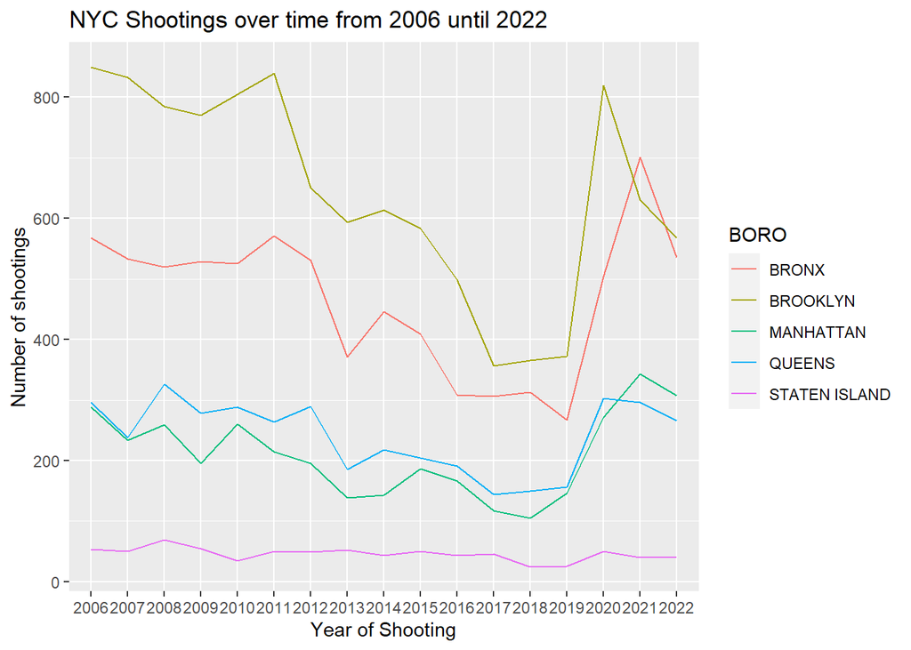

```r
# first plot the data by year and color by borough.
ggplot(nyc_yearaggregate, aes(x = OCCUR_YEAR, y = n, group=BORO, color=BORO)) + geom_line() + ggtitle("NYC Shootings over time from 2006 until 2022") + ylab("Number of shootings") + xlab("Year of Shooting")
```

The second and third visualizations we’d like to see if there was an increase in shootings by a specific day or by a specific month.

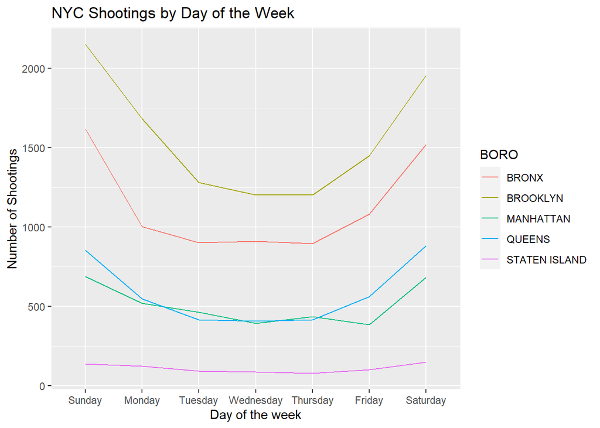

```r
# first plot the data by year and color by borough.

nyc_dayaggregate$od <- factor(nyc_dayaggregate$OCCUR_DAY, levels = c("Sunday", "Monday", "Tuesday", "Wednesday", "Thursday", "Friday", "Saturday"))

ggplot(nyc_dayaggregate, aes(x = od, y = n, group = BORO, color = BORO)) + geom_line() + ggtitle("NYC Shootings by Day of the Week") + ylab("Number of Shootings") + xlab("Day of the week")
```

From the above plot we can see the increase in shooting incidents over the course of the weekend days Friday through Monday and a lower reduction from Tuesday through Thursday. This isn’t too surprising.

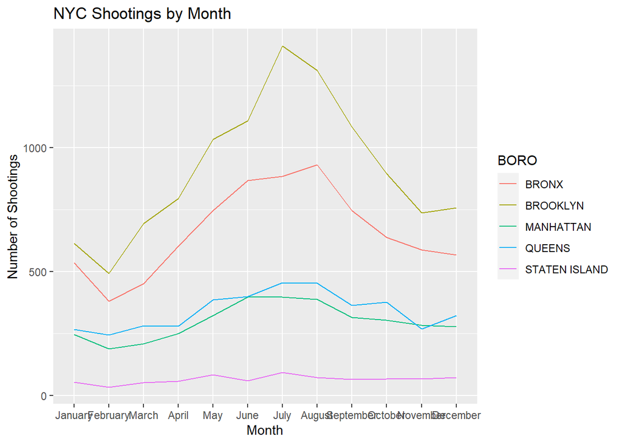

```r
nyc_monthaggregate$om <- factor(nyc_monthaggregate$OCCUR_MONTH, levels = c("January", "February", "March", "April", "May", "June", "July", "August", "September", "October", "November", "December"))


ggplot(nyc_monthaggregate, aes(x = om, y = n, group = BORO, color = BORO)) + geom_line() + ggtitle("NYC Shootings by Month") + ylab("Number of Shootings") + xlab("Month")
```

Here again not too surprising we see a sharp increase during the summer months and a reduction during the winter months.

## Modeling

Here we just want to do a very simple model to see if there is a correlation between the number of shootings and year of occurrence. This would tell us if there is a linear relationship of the number of shootings over time or if there more of a random relationship between the number of shootings within a year.

```r
fit.model.year <- lm(OCCUR_YEAR ~ n, nyc_yearaggregate)

summary(fit.model.year)
```

```
##
## Call:
## lm(formula = OCCUR_YEAR ~ n, data = nyc_yearaggregate)
##
## Residuals:
##    Min     1Q Median     3Q    Max
## -8.813 -4.101 -0.177  3.975  8.747
##
## Coefficients:
##               Estimate Std. Error  t value Pr(>|t|)
## (Intercept)  2.015e+03  9.091e-01 2216.536   <2e-16 ***
## n           -3.029e-03  2.294e-03   -1.321     0.19
## ---
## Signif. codes:  0 '***' 0.001 '**' 0.01 '*' 0.05 '.' 0.1 ' ' 1
##
## Residual standard error: 4.906 on 83 degrees of freedom
## Multiple R-squared:  0.02058,    Adjusted R-squared:  0.008784
## F-statistic: 1.744 on 1 and 83 DF,  p-value: 0.1902
```

From this you can see that there is a non significant p-value in both the F-statistic and the t-statistic showing that there is no linear relationship between number of shootings in a year and the year of occurrence. This would suggest that there was no linear increase in shootings over a year time period.

## Bias

There are potential sources of bias inherit within the data. First, this simply just took the number of shootings from within each borough, but to get a better idea of the crime rate a better analysis would have taken the per capita shootings and divided it by population. That would have been a proper scale for the analysis. Second, reported shootings decreased in years, and increased in others. This doesn’t get a feel for rationale behind such drops. Third, the methodology for reporting shootings might incur some bias as to how the data was collected. Was this reported by hospitals, law enforcement, or self reporting? Do these sources provide reliable data collection or some hidden bias? All of this is potentially biasing whatever analysis is performed on the data.